# Animal Nervous Systems

## Things to Know (#s)

- **#CNS**
- **#PNS**
- **#Vertebrate Brain**

## Most animals possess a nervous system

- **Early forms of ‘sense-react’ existed in prokaryotes (not animals)**
- **During the Cambrian explosion, specialized nervous systems appeared**
  - allowed animals to sense environment
  - allowed animals to respond quickly
- **Cnidarians are the simplest organisms with nervous systems**
  - nerve nets scattered throughout body
  - control contraction & expansion of gastrovascular cavity

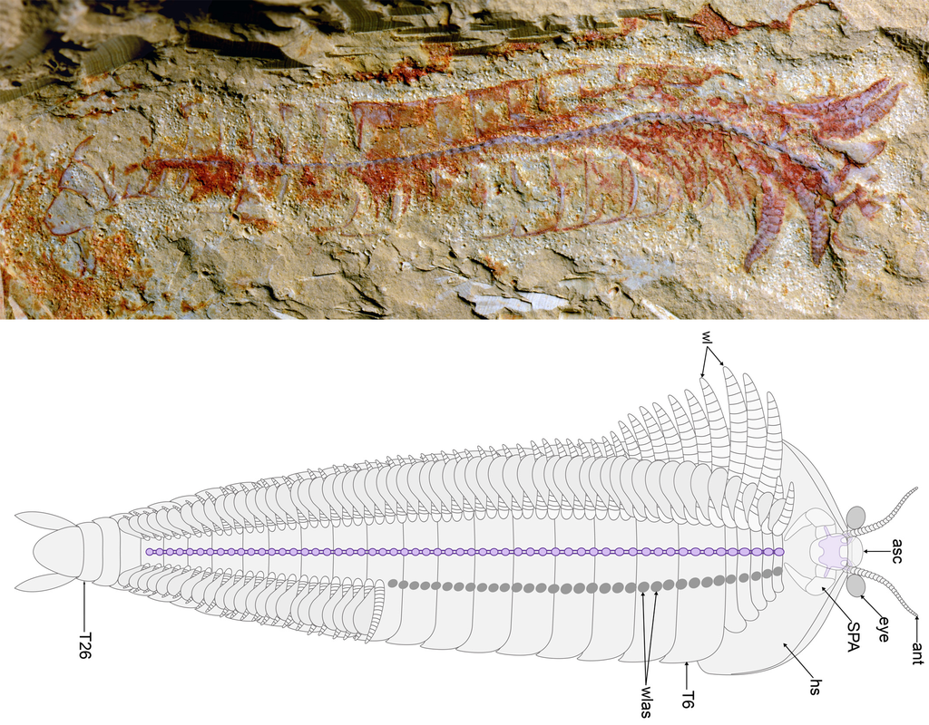

## Nerve net in jellyfish

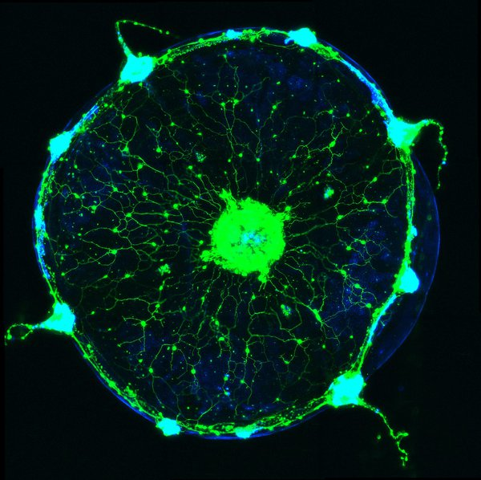

## Nervous systems consist of circuits of neurons and cells

- **In complex animals, axons of many *neurons* are bundled into ‘nerves’ with other tissues**
- **Fibrous-like nerves channel information flow along targeted routes in the nervous system**
- **Nerve circuits differ across the animal phylogeny**
  - radially symmetric - nerves connected to central ring (decentralized)
  - bilaterial animals - *cephalization*

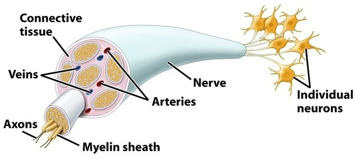

## Central nervous systems (CNS)

- **Many animals have neurons that carry out integration (i.e., perception) formed into a CNS**
  - *interneurons - process, integrate, and relay signals enabling complex functions*
- **Planaria (flat worms) represent the first defined CNS**
  - small brain and 2 nerve cords
  - only a few hundred neurons
- **Higher animals have more complicated brains and nerve cords with ganglia**
  - ganglia - clusters of nerves at at key points in the body. Serve as relay points or simple control centers

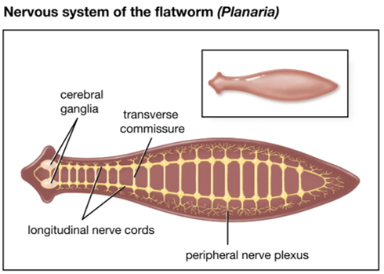

## Nervous system organization also matches lifestyle

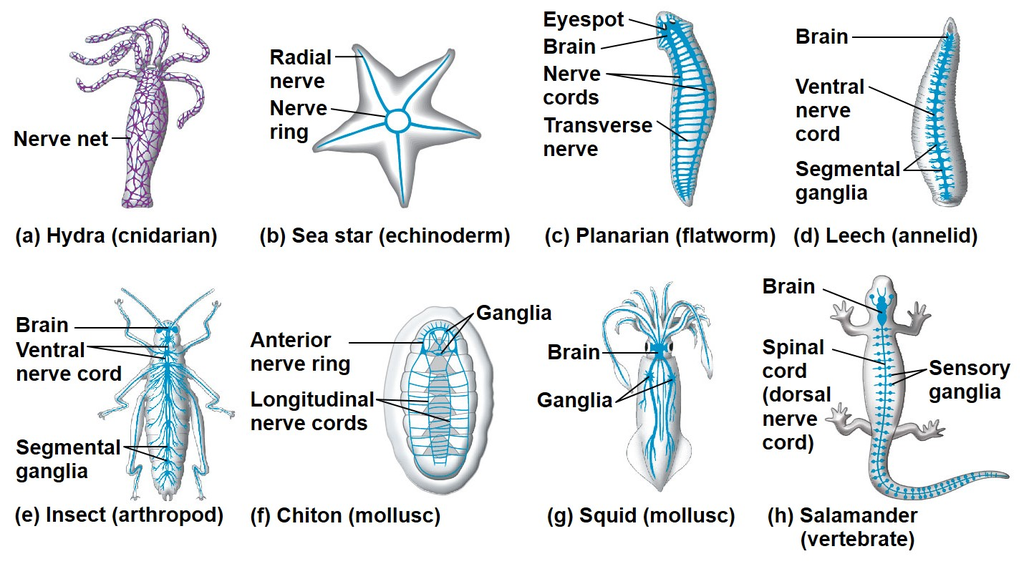

## Peripheral nervous system (PNS) relays info to/from the CNS

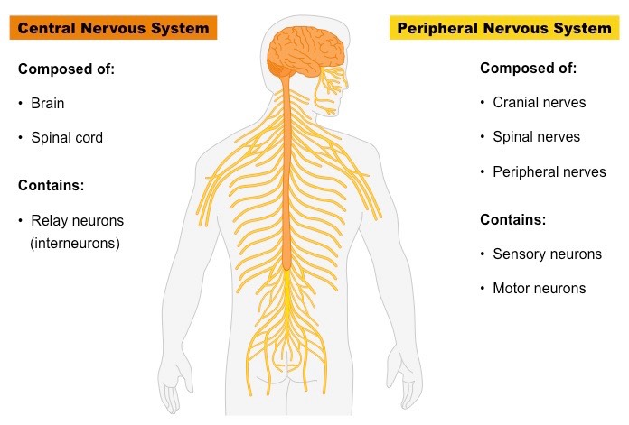

## Vertebrate nervous systems

- **CNS develops from hollow dorsal nerve cord**
  - central canal of spinal cord
  - hollow cavities (*ventricles*) of brain
- **Brain & spinal cord have grey and white matter**
  - *grey* = neuron cell bodies, dendrites, terminals
  - *white* = bundled axons
- **Gray matter is where processing and integration occurs, while white matter connects regions by carrying signals between them**
- **White matter is found on the outer layer of the spinal cord, where it links the CNS to the PNS, and in the interior of the brain, where it transmits signals between different regions**

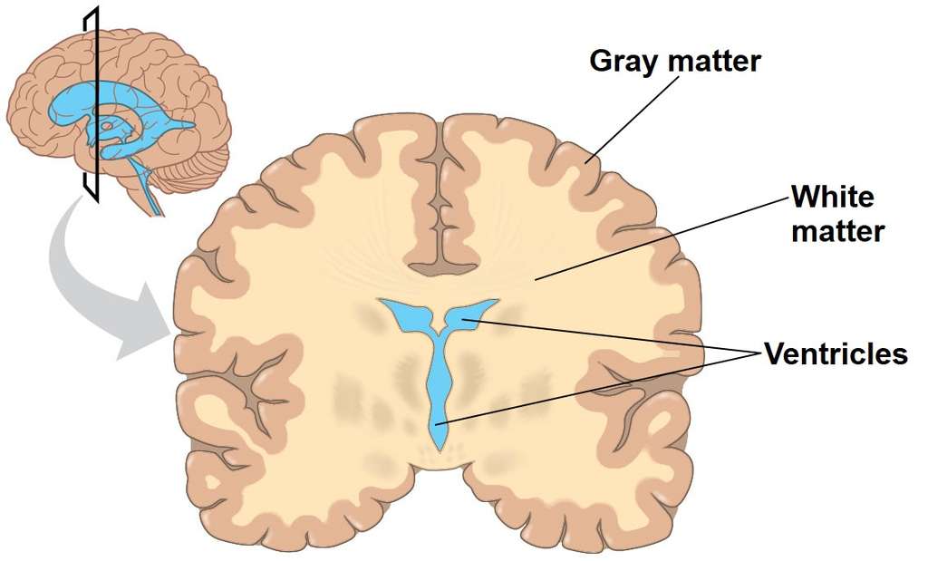

## Spinal cords carry information between the brain and body

**Can act independently for simple *rapid* reflexes**

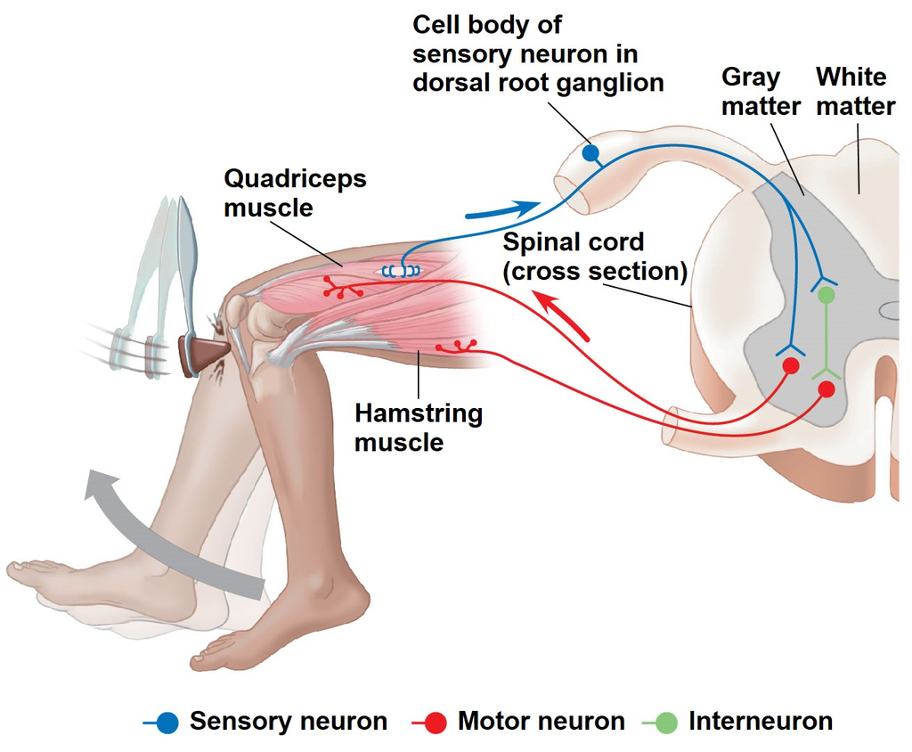

## PNS plays a large role in animal movement/homeostasis

- **Sensory information reaches the CNS along PNS sensory neurons**
  - *afferent* neurons = to carry towards
- **CNS processes information and sends instructions to muscles, glands, and other organs through motor neurons**
  - *efferent* neurons = to carry away
- **Nerve bundles include both afferent and efferent neurons, sending signals in opposite directions**

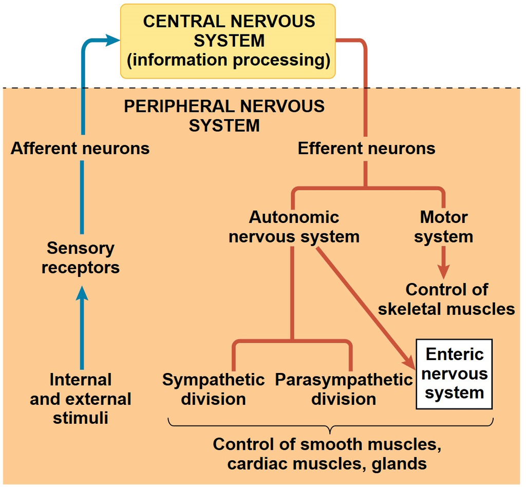

## PNS plays a large role in animal movement/homeostasis

- **PNS has 2 efferent components**
  - *motor* system
  - *autonomic* nervous system
- **Motor system carry signals to skeletal muscles**
  - voluntary (raise a hand)
  - involuntary knee-jerk
- **Autonomic system regulates *involuntary* smooth (organs) and cardiac muscles**
  - *Sympathetic*, *Parasympathetic*, *Enteric*
  - *Enteric* = controls digestion

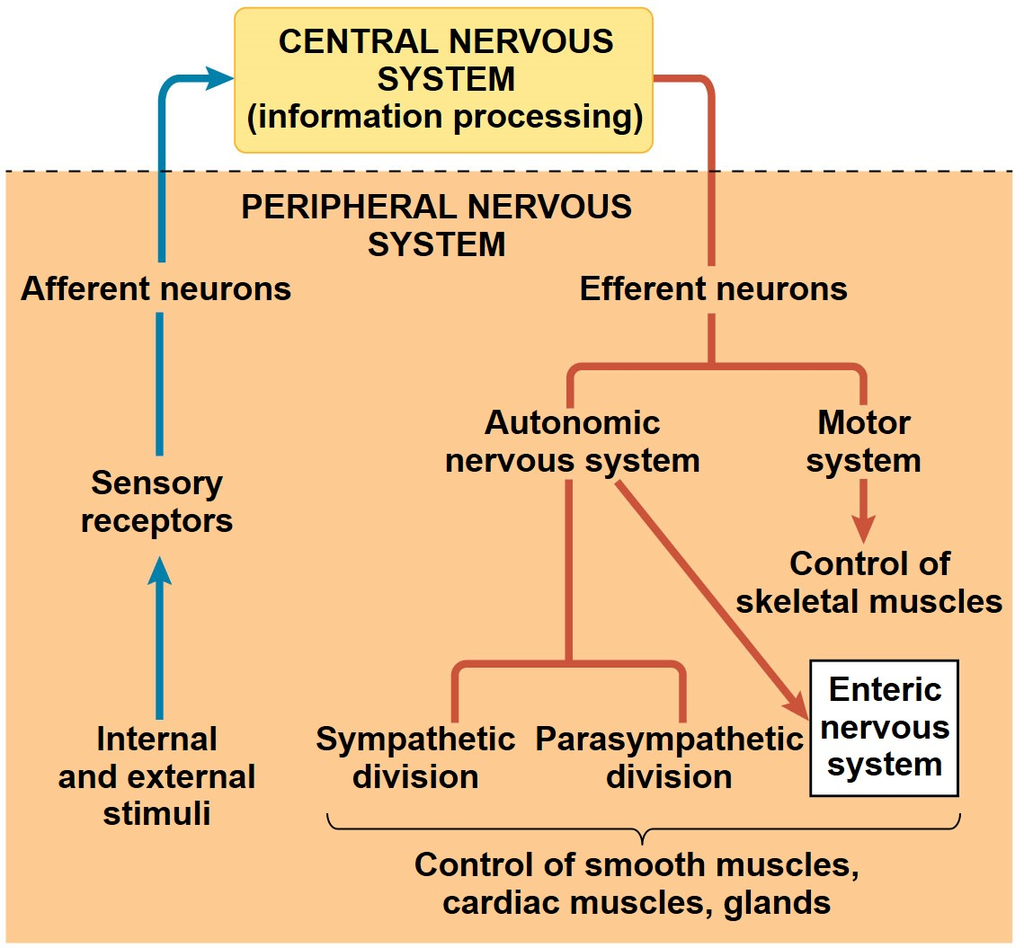

## Parasympathetic and Sympathetic divisions are antagonistic

**Calming and self-maintenance (para) vs arousal and energy generation (symp)**

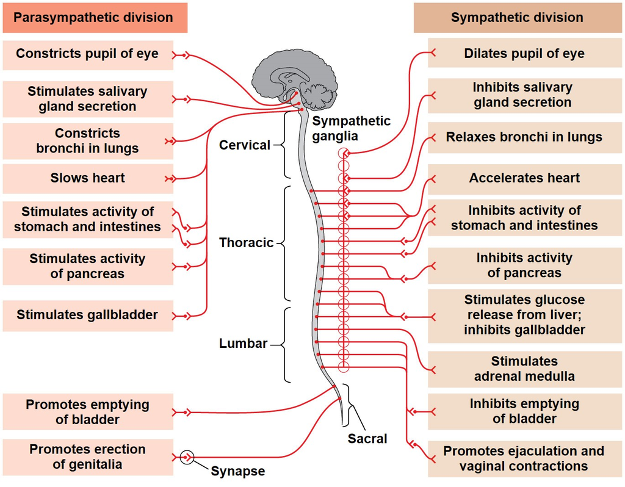

## Vertebrate brain is specialized by region

**Across vertebrates, sizes of each region reflect importance of functions to each animal**

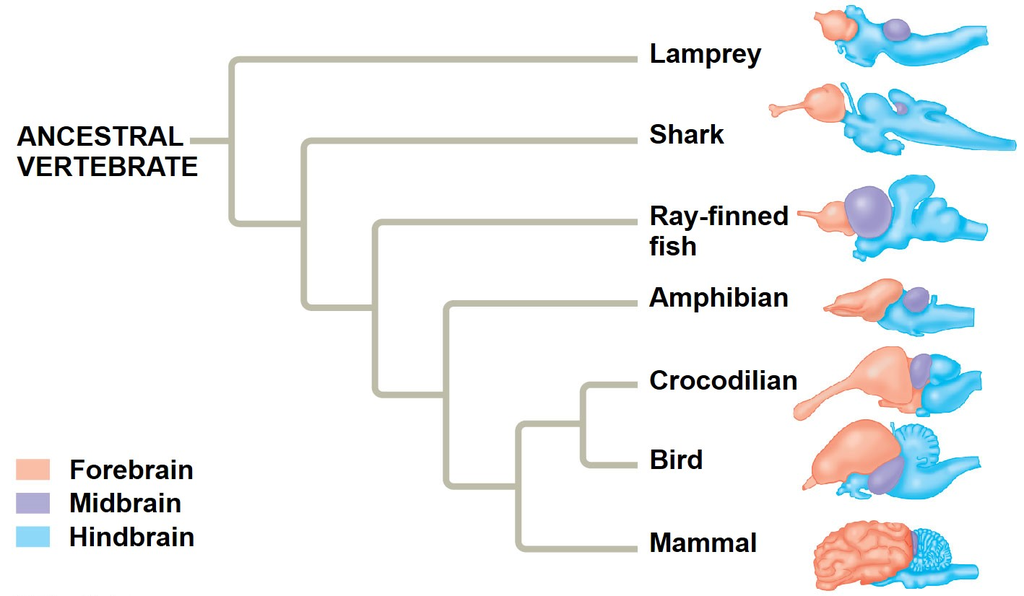

## Birds and mammals have larger brain:body size ratios

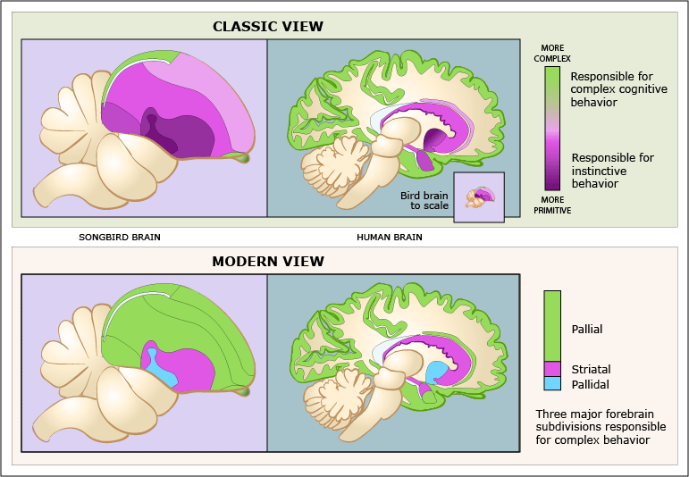

## Human brain

**100 billion neurons make 100 trillion connections**

**Cerebrum (enhanced region of forebrain) is essential for language, cognition, memory, consciousness and awareness**

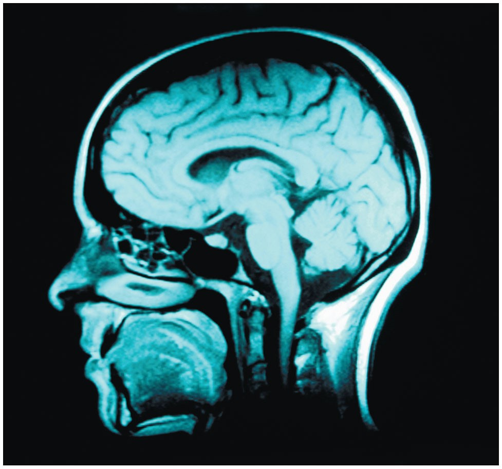

## Human brain

**100 billion neurons make 100 trillion connections**

**Cerebrum is essential for language, cognition, memory, consciousness and awareness**

- **Cerebrum is also regionized ( Don’t Memorize)**
  - Frontal lobe = temperament and decisions
  - Temporal lobe = hearing
  - Paretial lobe = touch and integration
  - Occipital lobe = vision

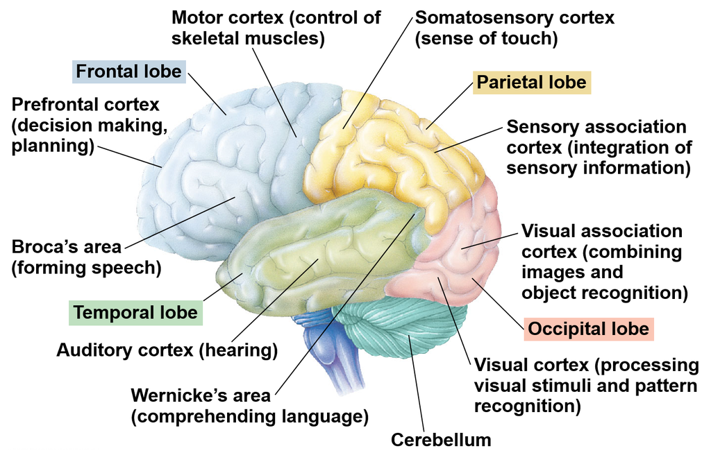